# Clustering dataset Covid

Jorge Arias

02/09/2020

0. - Parámetros

```r
options(scipen=999)#Desactiva la notación científica
```

1. - Preparación del entorno 1.1 - Cargamos las librerías que vamos a utilizar

```r
#lista de paquetes que vamos a usar
paquetes <- c('data.table',#para leer y escribir datos de forma rapida
              'dplyr',#para manipulación de datos
              'tidyr',#para manipulación de datos
              'ggplot2',#para gráficos
              'TeachingDemos', #para caras de chernoff
              'aplpack' #caras chernoff

)
#Crea un vector lógico con si están instalados o no
instalados <- paquetes %in% installed.packages()
#Si hay al menos uno no instalado los instala
if(sum(instalados == FALSE) > 0) {
  install.packages(paquetes[!instalados])
}
lapply(paquetes,require,character.only = TRUE)
```

```
## [[1]]
## [1] TRUE
##
## [[2]]
## [1] TRUE
##
## [[3]]
## [1] TRUE
##
## [[4]]
## [1] TRUE
##
## [[5]]
## [1] TRUE
##
## [[6]]
## [1] TRUE
```

1.2 - Cargamos los datos Usamos fread de data.table para una lectura mucho mas rapida

```r
df <- fread('agregados.csv')
```

2 - Análisis exploratorio 2.1 - Análisis exploratorio general y tipo de datos

```r
as.data.frame(sort(names(df)))
```

```
##   sort(names(df))
## 1           CASOS
## 2            CCAA
## 3      Fallecidos
## 4           FECHA
## 5  Hospitalizados
## 6            PCR+
## 7         TestAc+
## 8             UCI
```

```r
str(df)
```

```
## Classes 'data.table' and 'data.frame':   1737 obs. of  8 variables:
##  $ CCAA          : chr  "AN" "AR" "AS" "IB" ...
##  $ FECHA         : chr  "20/2/2020" "20/2/2020" "20/2/2020" "20/2/2020" ...
##  $ CASOS         : int  0 NA NA NA NA NA NA NA NA NA ...
##  $ PCR+          : int  0 0 0 1 1 0 0 0 0 0 ...
##  $ TestAc+       : int  NA NA NA NA NA NA NA NA NA NA ...
##  $ Hospitalizados: int  NA NA NA NA NA NA NA NA NA NA ...
##  $ UCI           : int  NA NA NA NA NA NA NA NA NA NA ...
##  $ Fallecidos    : int  NA NA NA NA NA NA NA NA NA NA ...
##  - attr(*, ".internal.selfref")=<externalptr>
```

```r
glimpse(df)
```

```
## Rows: 1,737
## Columns: 8
## $ CCAA           <chr> "AN", "AR", "AS", "IB", "CN", "CB", "CM", "CL", "CT"...
## $ FECHA          <chr> "20/2/2020", "20/2/2020", "20/2/2020", "20/2/2020", ...
## $ CASOS          <int> 0, NA, NA, NA, NA, NA, NA, NA, NA, NA, NA, NA, NA, N...
## $ `PCR+`         <int> 0, 0, 0, 1, 1, 0, 0, 0, 0, 0, 0, 0, 0, 1, 0, 0, 0, 0...
## $ `TestAc+`      <int> NA, NA, NA, NA, NA, NA, NA, NA, NA, NA, NA, NA, NA, ...
## $ Hospitalizados <int> NA, NA, NA, NA, NA, NA, NA, NA, NA, NA, 26, NA, NA, ...
## $ UCI            <int> NA, NA, NA, NA, NA, NA, NA, NA, NA, NA, 0, NA, NA, N...
## $ Fallecidos     <int> NA, NA, NA, NA, NA, NA, NA, NA, NA, NA, NA, NA, NA, ...
```

2.2 - Calidad de datos: Estadísticos básicos Hacemos un summary, con lapply que sale en formato de lista y se lee mejor

```r
lapply(df,summary)
```

```
## $CCAA
##    Length     Class      Mode
##      1737 character character
##
## $FECHA
##    Length     Class      Mode
##      1737 character character
##
## $CASOS
##    Min. 1st Qu.  Median    Mean 3rd Qu.    Max.    NA's
##       0       0       0       0       0       0    1736
##
## $`PCR+`
##    Min. 1st Qu.  Median    Mean 3rd Qu.    Max.    NA's
##       0      71    1752    6323    5858   67049       8
##
## $`TestAc+`
##    Min. 1st Qu.  Median    Mean 3rd Qu.    Max.    NA's
##       0     114     873    1509    2023    8634    1044
##
## $Hospitalizados
##    Min. 1st Qu.  Median    Mean 3rd Qu.    Max.    NA's
##       0     260    1080    4182    4397   42497     336
##
## $UCI
##    Min. 1st Qu.  Median    Mean 3rd Qu.    Max.    NA's
##     0.0    29.0   118.0   399.4   420.5  3617.0     306
##
## $Fallecidos
##    Min. 1st Qu.  Median    Mean 3rd Qu.    Max.    NA's
##     0.0    17.0   197.0   810.5   773.0  8931.0     323
```

2.3 - Calidad de datos: Análisis de nulos

```r
data.frame(colSums(is.na(df)))
```

```
##                colSums.is.na.df..
## CCAA                            0
## FECHA                           0
## CASOS                        1736
## PCR+                            8
## TestAc+                      1044
## Hospitalizados                336
## UCI                           306
## Fallecidos                    323
```

Observaciones: Encontramos un alto numero de núlos, los convertiremos a ceros.

2.4 - Acciones resultado del analisis de calidad de datos y exploratorio

```r
df <- df[1:1729, ]

df[is.na(df)] <- 0

df$FECHA <- as.Date(df$FECHA, format="%d/%m/%Y")
```

Hacemos nuevamente un Lapply para conocer de forma f;acil el rango de fechas del dataset

```r
lapply(df,summary)
```

```
## $CCAA
##    Length     Class      Mode
##      1729 character character
##
## $FECHA
##         Min.      1st Qu.       Median         Mean      3rd Qu.         Max.
## "2020-02-20" "2020-03-13" "2020-04-05" "2020-04-05" "2020-04-28" "2020-05-20"
##
## $CASOS
##    Min. 1st Qu.  Median    Mean 3rd Qu.    Max.
##       0       0       0       0       0       0
##
## $`PCR+`
##    Min. 1st Qu.  Median    Mean 3rd Qu.    Max.
##       0      71    1752    6323    5858   67049
##
## $`TestAc+`
##    Min. 1st Qu.  Median    Mean 3rd Qu.    Max.
##     0.0     0.0     0.0   604.8   475.0  8634.0
##
## $Hospitalizados
##    Min. 1st Qu.  Median    Mean 3rd Qu.    Max.
##       0      11     771    3389    2648   42497
##
## $UCI
##    Min. 1st Qu.  Median    Mean 3rd Qu.    Max.
##     0.0     3.0    91.0   330.5   291.0  3617.0
##
## $Fallecidos
##    Min. 1st Qu.  Median    Mean 3rd Qu.    Max.
##     0.0     1.0   115.0   662.9   503.0  8931.0
```

Ahora podemos comprobar que los datos recogidos son desde el 20-02-2020 al 20-05-2020

3. - Transformación de datos:

3.1. - Creación variable caso confirmados: Se usará la variable CASOS y se actualizará con la suma de PCR y TestAc+

```r
df$CASOS <- (df$`PCR+` + df$`TestAc+`)
```

3.2. - Agrupación de datos por CCAAs para obtener casos totales

```r
#los nombres de PCR+ y TestAC+ dan problema si no sustituyo el símbolo +, así que renombramos antes:

names(df)[4]<-"PCRs"
names(df)[5]<-"TestACs"

df_CCAA<-group_by(df, CCAA)
df_CCAA<-summarize(df_CCAA, count=n(),
               CONFIRMADOS=sum(CASOS, na.rm=T),
               PCRs=sum(PCRs, na.rm=T),
               TestAC=sum(TestACs, na.rm=T),
               Hospitalizados=sum(Hospitalizados, na.rm=T),
               UCIs=sum(UCI, na.rm=T),
               Fallecidos=sum(Fallecidos,na.rm = T))
```

Comprobamos resultados, ordenando salida de menor a mayor casos confirmados

```r
df_CCAA %>%
  arrange(CONFIRMADOS)
```

```
## # A tibble: 19 x 8
##    CCAA  count CONFIRMADOS    PCRs TestAC Hospitalizados   UCIs Fallecidos
##    <chr> <int>       <dbl>   <int>  <dbl>          <dbl>  <dbl>      <dbl>
##  1 ML       91        6319    5954    365           2393    174        106
##  2 CE       91        6739    5212   1527            509    215        193
##  3 IB       91       99690   96940   2750          51664   8315       8409
##  4 MC       91      101495   80381  21114          32490   5614       6051
##  5 CN       91      115311  115311      0          46386   8953       6562
##  6 CB       91      120897  108939  11958          49991   4155       8331
##  7 AS       91      144062  120402  23660          53122   6277      11458
##  8 EX       91      176636  147511  29125          73215   5916      20791
##  9 RI       91      243087  199022  44065          69281   4594      14809
## 10 AR       91      287873  252213  35660         121476  13162      33060
## 11 NC       91      303716  244856  58860         100666   7334      19779
## 12 GA       91      471562  440226  31336         137403  16382      21913
## 13 VC       91      609998  531901  78097         272179  36069      57242
## 14 AN       91      682382  604059  78323         297285  35354      54237
## 15 PV       91      765310  648620 116690         338296  28028      58808
## 16 CL       91      948423  808285 140138         389478  27191      81088
## 17 CM       91      975754  791554 184200         436771  32533     113396
## 18 CT       91     2394239 2352187  42052        1267248 135069     225775
## 19 MD       91     3524268 3378452 145816        2119014 196181     404108
```

3.3. - Salvamos dataset limpio:

```r
saveRDS(df_CCAA,'df_CCAA.rds')
```

4. - Comprobamos las caras de Chernoff

```r
CARAS<-TeachingDemos::faces(df_CCAA[,3:8])
```

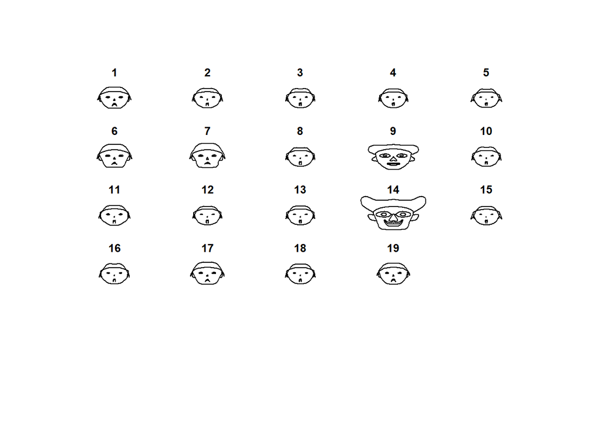

Ahora las observaremos con mas detalles y color

```r
library(aplpack)

CCAAfaces <- faces(df_CCAA[,3:8], labels = row.names(df_CCAA), face.type =5)
```

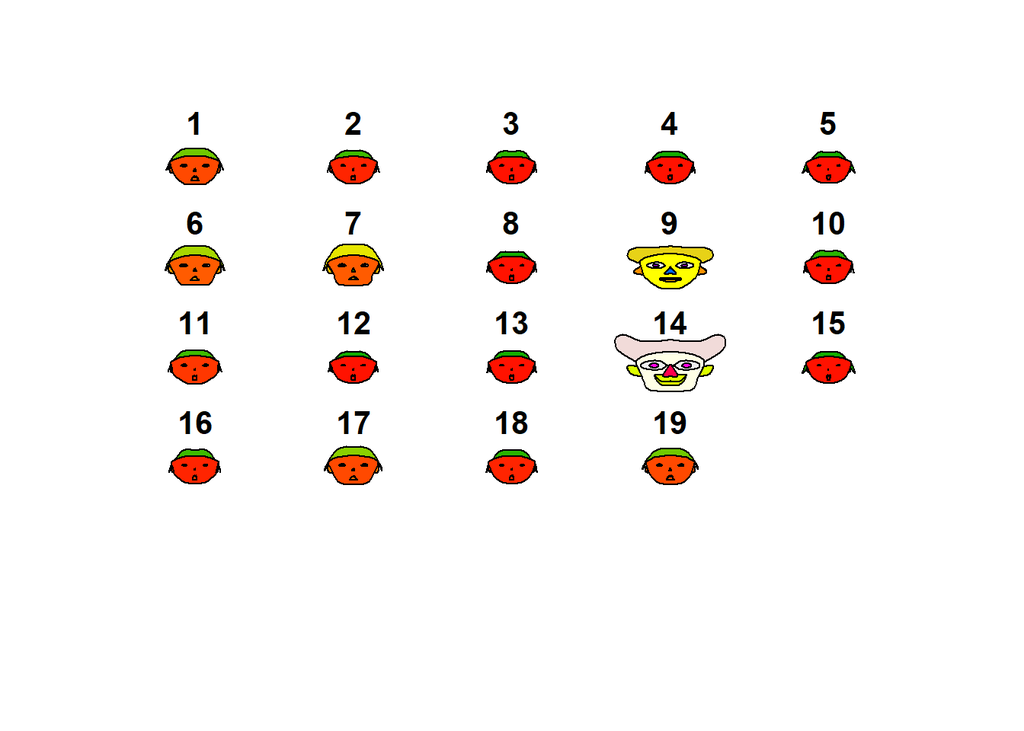

```
## effect of variables:
##  modified item       Var
##  "height of face   " "CONFIRMADOS"
##  "width of face    " "PCRs"
##  "structure of face" "TestAC"
##  "height of mouth  " "Hospitalizados"
##  "width of mouth   " "UCIs"
##  "smiling          " "Fallecidos"
##  "height of eyes   " "CONFIRMADOS"
##  "width of eyes    " "PCRs"
##  "height of hair   " "TestAC"
##  "width of hair   "  "Hospitalizados"
##  "style of hair   "  "UCIs"
##  "height of nose  "  "Fallecidos"
##  "width of nose   "  "CONFIRMADOS"
##  "width of ear    "  "PCRs"
##  "height of ear   "  "TestAC"
```

```r
row.names(df_CCAA) <- df_CCAA$CCAA
```

5. - Clustering

5.1. - Clustering con MST

```r
porCCAAs <- hclust(dist(df_CCAA,method="euclidian"),method="single")
```

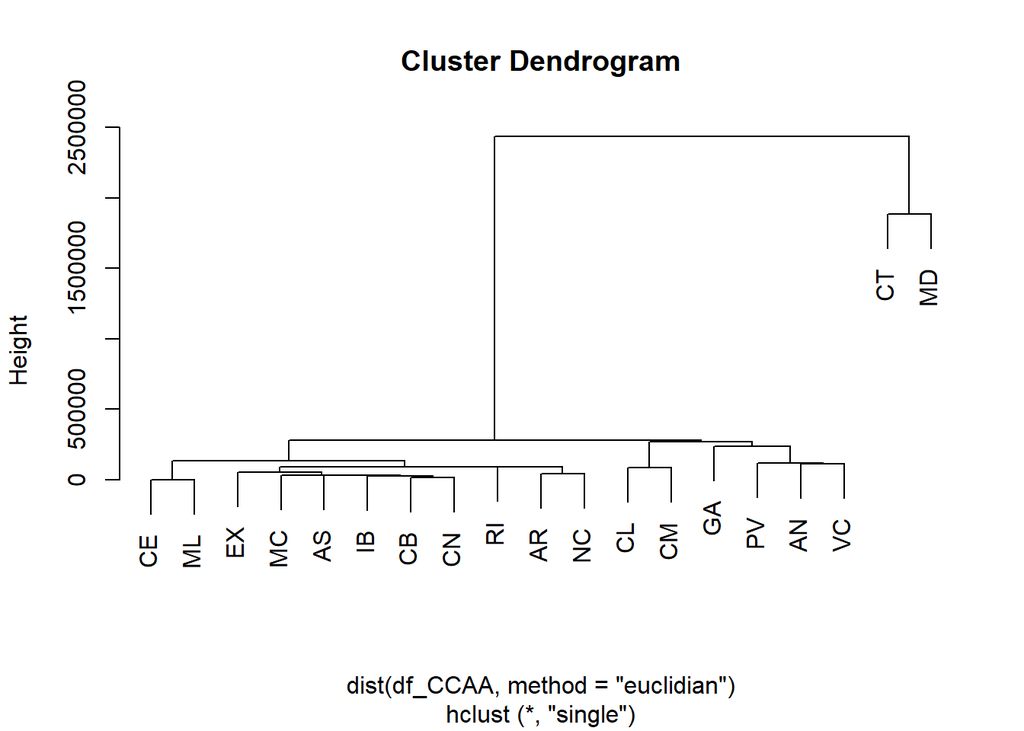

```r
plot(porCCAAs)
plot(hclust(dist(df_CCAA,method="euclidian"),method="single"))
```

5.2. - Clustering con KMEANS

```r
# Trabajamos con la base de datos df_CCAA
# Primero vamos a escalar los datos para equilibrar los calculos

datos <- as.data.frame(scale(df_CCAA[, 3:8]))

# asignamos una semilla para garantizar la aleatoriedad de la primera asignacion

set.seed(123)

# Creamos los clusteres mediante kmeans

datos.kmeans <- kmeans(datos, centers = 6)
# k=centers

# observamos los resultados y la calidad de los mismos
datos.kmeans
```

```
## K-means clustering with 6 clusters of sizes 5, 2, 3, 4, 3, 2
##
## Cluster means:
##   CONFIRMADOS        PCRs     TestAC Hospitalizados         UCIs  Fallecidos
## 1 -0.62605539 -0.58894706 -0.9393934    -0.52917407 -0.511723209 -0.56036199
## 2  2.60067972  2.65015340  0.7064742     2.63427658  2.697071186  2.56609353
## 3 -0.54683513 -0.53151409 -0.5522747    -0.48588916 -0.480418435 -0.47926853
## 4 -0.33931578 -0.33710979 -0.2281061    -0.38266128 -0.392224109 -0.38228065
## 5  0.06196506  0.02255604  0.6538485    -0.01098544  0.061097514 -0.03587378
## 6  0.37039541  0.25987091  1.9458609     0.19929303 -0.004333563  0.37208621
##
## Clustering vector:
##  [1] 5 4 3 1 1 6 6 1 2 3 4 1 3 2 1 4 5 4 5
##
## Within cluster sum of squares by cluster:
## [1] 0.11164268 6.94477816 0.03203429 0.29062339 0.37487819 0.38361500
##  (between_SS / total_SS =  92.5 %)
##
## Available components:
##
## [1] "cluster"      "centers"      "totss"        "withinss"     "tot.withinss"
## [6] "betweenss"    "size"         "iter"         "ifault"
```

```r
str(datos.kmeans)
```

```
## List of 9
##  $ cluster     : int [1:19] 5 4 3 1 1 6 6 1 2 3 ...
##  $ centers     : num [1:6, 1:6] -0.626 2.601 -0.547 -0.339 0.062 ...
##   ..- attr(*, "dimnames")=List of 2
##   .. ..$ : chr [1:6] "1" "2" "3" "4" ...
##   .. ..$ : chr [1:6] "CONFIRMADOS" "PCRs" "TestAC" "Hospitalizados" ...
##  $ totss       : num 108
##  $ withinss    : num [1:6] 0.112 6.945 0.032 0.291 0.375 ...
##  $ tot.withinss: num 8.14
##  $ betweenss   : num 99.9
##  $ size        : int [1:6] 5 2 3 4 3 2
##  $ iter        : int 2
##  $ ifault      : int 0
##  - attr(*, "class")= chr "kmeans"
```

5.2.1. - Metricas

```r
#Inercia ENTRE grupos:  mayor es mejor
datos.kmeans$betweenss
```

```
## [1] 99.86243
```

```r
#Inercia INTRA grupos:  menor es mejor
datos.kmeans$withinss
```

```
## [1] 0.11164268 6.94477816 0.03203429 0.29062339 0.37487819 0.38361500
```

```r
#Inercia total INTRA grupos:  menor es mejor
datos.kmeans$tot.withinss
```

```
## [1] 8.137572
```

```r
#Representamos los resultados

comunidades<-df_CCAA$CCAA
grupo<-datos.kmeans$cluster
datosc<-data.frame(comunidades, grupo)
```

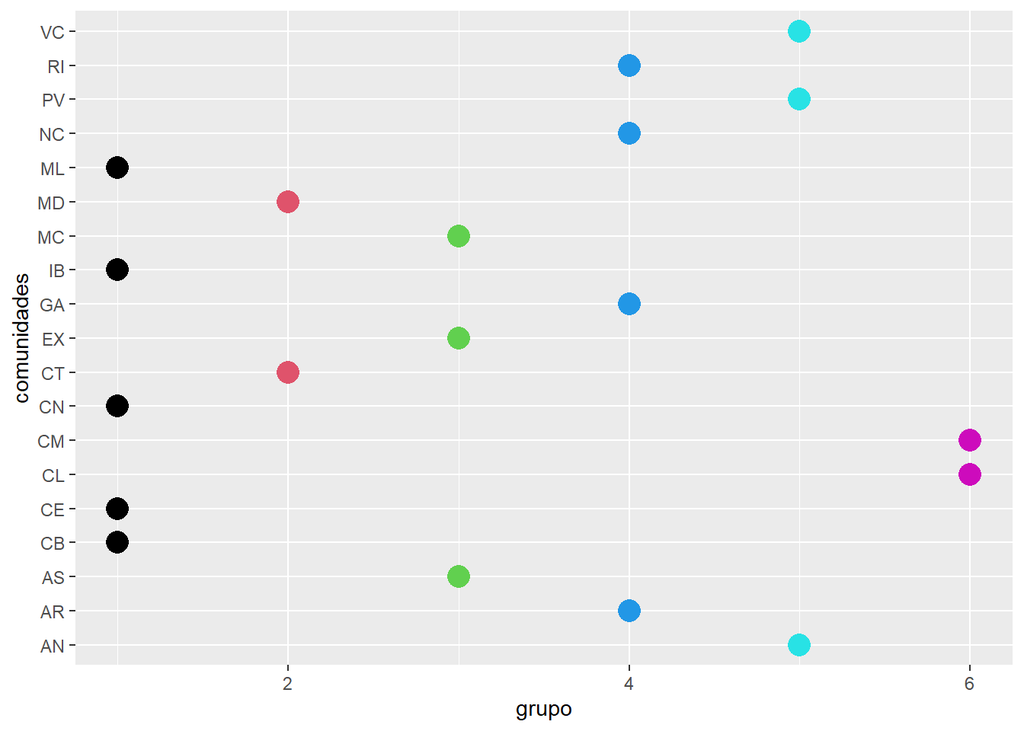

```r
ggplot(datosc)+
  geom_point(mapping=aes(x=grupo, y=comunidades),color=grupo, size=5)
```

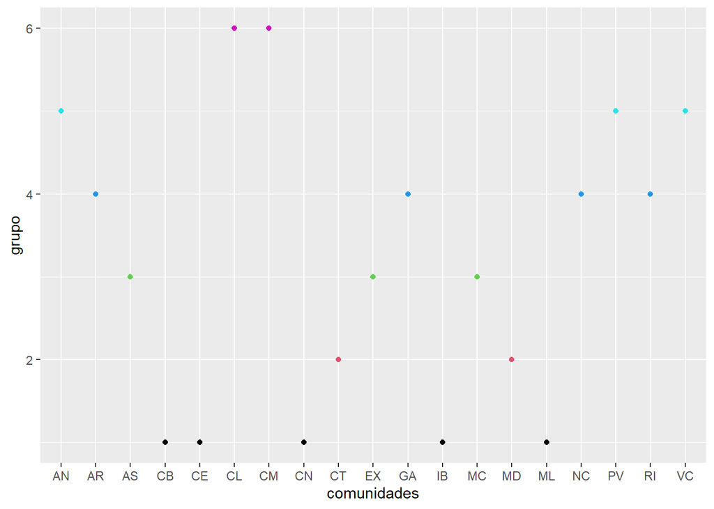

```r
ggplot(datosc)+
 geom_point(mapping=aes(x=comunidades, y=grupo),color=grupo)
```